# Lab 6

Beatrix Jones

8/28/2019

### Q-values

I have written a function to compute Benjamini and Hochberg qvalues, with the option to modify pi0 (the proportion of variables that follow the null hypothesis). This can be used if you have difficulty installing the qvalue package.

```r
qval.pi0<-function(pvals, pi0=1){
  #pvals should not have missing values
  #default value of pi0 is 1, but another can be specified.
  ord<-order(pvals, decreasing = TRUE)
  pord<-pvals[ord]
answer.ord<-rep(NA,length(pvals) )
answer<-rep(NA, length(pvals))
  denominator<-sum(pord <= pord[1]) #number of discoveries using pord[i] as the threshold
  numerator<- pord[1]*length(pord)*pi0  #expected number of false discoveries
  answer.ord[1]<-numerator/denominator
        for(i in 1: length(pord)){
    denominator<-sum(pord <= pord[i])
    numerator<- pord[i]*length(pord)*pi0
    if( numerator/denominator <= min(answer.ord[1:(i-1)]) ) answer.ord[i]<-numerator/denominator
    if( numerator/denominator > min(answer.ord[1:(i-1)]) ) answer.ord[i]<- min(answer.ord[1:(i-1)])
  }
answer[ord]<-answer.ord
return(answer)
}
```

First, lets see what the results look like on a set of variables that all follow the null hypothesis, and therefore the p-values have a uniform distribution between 0 and 1.

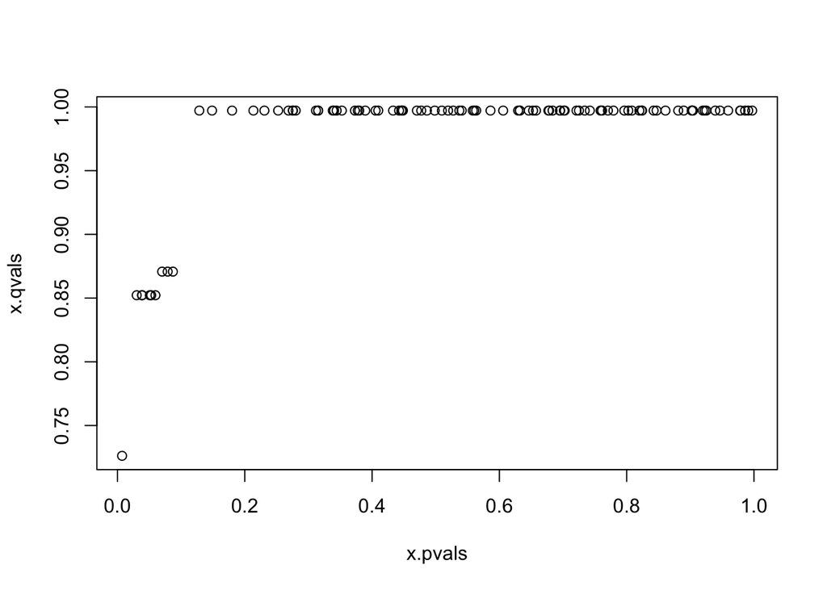

```r
set.seed(23579)  #use this if you want your plot to look exactly the same as the one below, or you may generate
#a different random set of p-values.
x.pvals<-runif(100)
x.qvals<-qval.pi0(x.pvals)
plot(x.pvals, x.qvals)
```

Note that, as desired in this “all null” data, none of the variables achieve a low qvalue (< 0.1 or 0.05), even though some of the pvalues are small:

```r
min(x.pvals)
```

```
## [1] 0.007262132
```

```r
sum(x.pvals< 0.05)
```

```
## [1] 4
```

```r
min(x.qvals)
```

```
## [1] 0.7262132
```

Now let’s try on some real data. This is data from the mixOmics package, but we will load the object directly rather than dealing with the package. Here the goal is to find genes that are differentially expressed across three cell types. Four hundred genes (columns) are considered; there are 125 observations, from 4 different studies.

```r
load("stemcells.RData")
names(stemcells)
```

```
## [1] "gene"     "study"    "celltype"
```

```r
table(stemcells$study, stemcells$celltype)
```

```
##
##     Fibroblast hESC hiPS
##   A          6   20   12
##   B          3    8   10
##   C         18    3   30
##   D          3    6    6
```

Thus if we were looking at a single gene expression measurement, we might use a blocked anova, with our primary interest being the effect associated with cell type.

```r
dim(stemcells$gene)
```

```
## [1] 125 400
```

```r
mod<-lm(stemcells$gene[,1]~factor(stemcells$study)+factor(stemcells$celltype))
anova(mod)
```

```
## Analysis of Variance Table
##
## Response: stemcells$gene[, 1]
##                             Df  Sum Sq  Mean Sq F value    Pr(>F)
## factor(stemcells$study)      3 0.43125 0.143750  62.914 < 2.2e-16 ***
## factor(stemcells$celltype)   2 0.34908 0.174542  76.390 < 2.2e-16 ***
## Residuals                  119 0.27190 0.002285
## ---
## Signif. codes:  0 '***' 0.001 '**' 0.01 '*' 0.05 '.' 0.1 ' ' 1
```

```r
anova(mod)[2,5]
```

```
## [1] 4.560901e-22
```

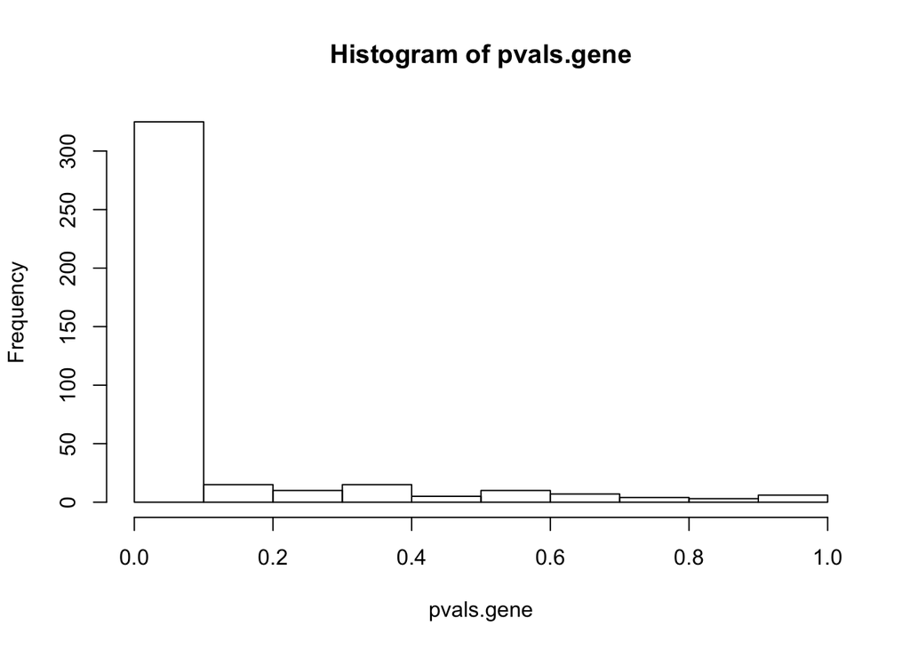

```r
pvals.gene<-rep(NA, 400)
for(i in 1:400){
  mod<-lm(stemcells$gene[,i]~factor(stemcells$study)+factor(stemcells$celltype))
anova(mod)
pvals.gene[i]<-anova(mod)[2,5]

}

hist(pvals.gene)
```

This definitely seems to not follow a uniform distribution! Let’s compute the q-values. As expected, many are small.

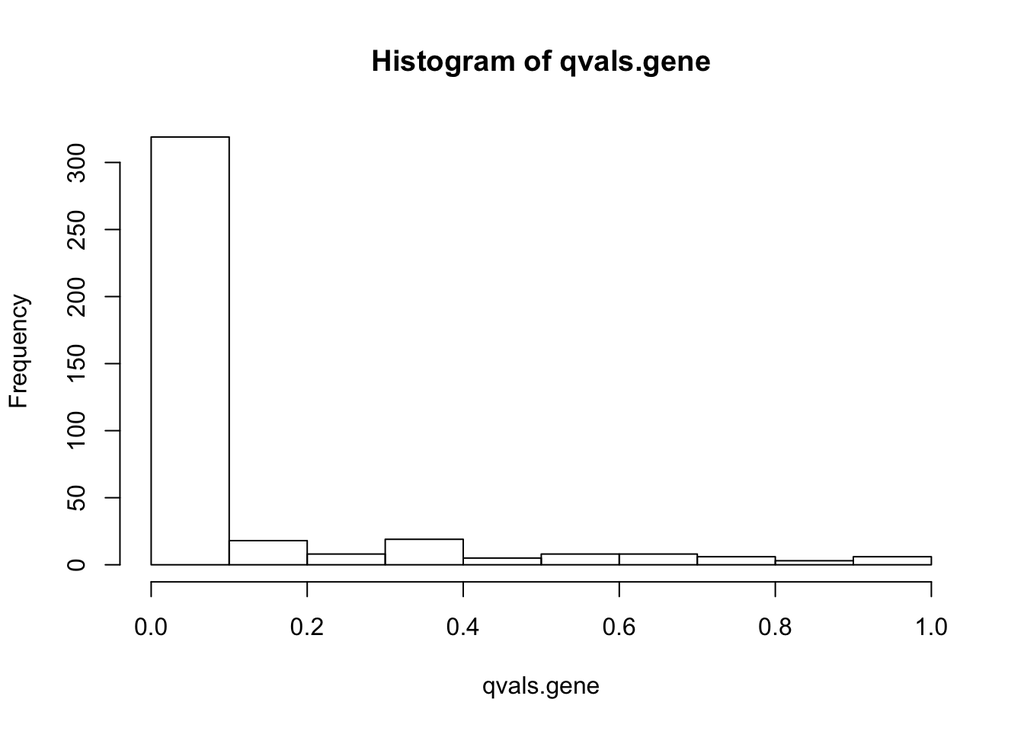

```r
qvals.gene<-qval.pi0(pvals.gene)
hist(qvals.gene)
```

```r
sum(qvals.gene< 0.05)
```

```
## [1] 306
```

```r
sum(qvals.gene< 0.01)
```

```
## [1] 280
```